# Unsupervised Lab Session

## Learning outcomes:

- Exploratory data analysis and data preparation for model building.
- PCA for dimensionality reduction.
- K-means and Agglomerative Clustering

## Problem Statement

Based on the given marketing campigan dataset, segment the similar customers into suitable clusters. Analyze the clusters and provide your insights to help the organization promote their business.

## Context:

- Customer Personality Analysis is a detailed analysis of a company’s ideal customers. It helps a business to better understand its customers and makes it easier for them to modify products according to the specific needs, behaviors and concerns of different types of customers.
- Customer personality analysis helps a business to modify its product based on its target customers from different types of customer segments. For example, instead of spending money to market a new product to every customer in the company’s database, a company can analyze which customer segment is most likely to buy the product and then market the product only on that particular segment.

## About dataset

- Source: https://www.kaggle.com/datasets/imakash3011/customer-personality-analysis?datasetId=1546318&sortBy=voteCount

### Attribute Information:

- ID: Customer's unique identifier
- Year_Birth: Customer's birth year
- Education: Customer's education level
- Marital_Status: Customer's marital status
- Income: Customer's yearly household income
- Kidhome: Number of children in customer's household
- Teenhome: Number of teenagers in customer's household
- Dt_Customer: Date of customer's enrollment with the company
- Recency: Number of days since customer's last purchase
- Complain: 1 if the customer complained in the last 2 years, 0 otherwise
- MntWines: Amount spent on wine in last 2 years
- MntFruits: Amount spent on fruits in last 2 years
- MntMeatProducts: Amount spent on meat in last 2 years
- MntFishProducts: Amount spent on fish in last 2 years
- MntSweetProducts: Amount spent on sweets in last 2 years
- MntGoldProds: Amount spent on gold in last 2 years
- NumDealsPurchases: Number of purchases made with a discount
- AcceptedCmp1: 1 if customer accepted the offer in the 1st campaign, 0 otherwise
- AcceptedCmp2: 1 if customer accepted the offer in the 2nd campaign, 0 otherwise
- AcceptedCmp3: 1 if customer accepted the offer in the 3rd campaign, 0 otherwise
- AcceptedCmp4: 1 if customer accepted the offer in the 4th campaign, 0 otherwise
- AcceptedCmp5: 1 if customer accepted the offer in the 5th campaign, 0 otherwise
- Response: 1 if customer accepted the offer in the last campaign, 0 otherwise
- NumWebPurchases: Number of purchases made through the company’s website
- NumCatalogPurchases: Number of purchases made using a catalogue
- NumStorePurchases: Number of purchases made directly in stores
- NumWebVisitsMonth: Number of visits to company’s website in the last month

### 1. Import required libraries

```python
import numpy as np
import pandas as pd
import matplotlib.pyplot as plt
import seaborn as sns
import warnings
warnings.filterwarnings("ignore")
from sklearn.preprocessing import LabelEncoder
from scipy.cluster.hierarchy import linkage, dendrogram
from sklearn.model_selection import train_test_split
from sklearn.cluster import KMeans
from sklearn.metrics import silhouette_score
from sklearn.metrics import classification_report,confusion_matrix,roc_curve,accuracy_score,auc,roc_auc_score
from sklearn.ensemble import RandomForestClassifier
from sklearn.preprocessing import StandardScaler,MinMaxScaler
from sklearn.discriminant_analysis import LinearDiscriminantAnalysis as LDA
from sklearn.decomposition import PCA
```

### 2. Load the CSV file (i.e marketing.csv) and display the first 5 rows of the dataframe. Check the shape and info of the dataset.

```python
df = pd.read_csv('marketing.csv')
df.head()
```

|  | ID | Year_Birth | Education | Marital_Status | Income | Kidhome | Teenhome | Dt_Customer | Recency | MntWines | ... | NumCatalogPurchases | NumStorePurchases | NumWebVisitsMonth | AcceptedCmp3 | AcceptedCmp4 | AcceptedCmp5 | AcceptedCmp1 | AcceptedCmp2 | Complain | Response |
| --- | --- | --- | --- | --- | --- | --- | --- | --- | --- | --- | --- | --- | --- | --- | --- | --- | --- | --- | --- | --- | --- |
| 0 | 5524 | 1957 | Graduation | Single | 58138.0 | 0 | 0 | 4/9/2012 | 58 | 635 | ... | 10 | 4 | 7 | 0 | 0 | 0 | 0 | 0 | 0 | 1 |
| 1 | 2174 | 1954 | Graduation | Single | 46344.0 | 1 | 1 | 8/3/2014 | 38 | 11 | ... | 1 | 2 | 5 | 0 | 0 | 0 | 0 | 0 | 0 | 0 |
| 2 | 4141 | 1965 | Graduation | Together | 71613.0 | 0 | 0 | 21-08-2013 | 26 | 426 | ... | 2 | 10 | 4 | 0 | 0 | 0 | 0 | 0 | 0 | 0 |
| 3 | 6182 | 1984 | Graduation | Together | 26646.0 | 1 | 0 | 10/2/2014 | 26 | 11 | ... | 0 | 4 | 6 | 0 | 0 | 0 | 0 | 0 | 0 | 0 |
| 4 | 5324 | 1981 | PhD | Married | 58293.0 | 1 | 0 | 19-01-2014 | 94 | 173 | ... | 3 | 6 | 5 | 0 | 0 | 0 | 0 | 0 | 0 | 0 |

5 rows × 27 columns

```python
df.shape
```

```
(2240, 27)
```

```python
df.info()
```

```
<class 'pandas.core.frame.DataFrame'>
RangeIndex: 2240 entries, 0 to 2239
Data columns (total 27 columns):
 #   Column               Non-Null Count  Dtype
---  ------               --------------  -----
 0   ID                   2240 non-null   int64
 1   Year_Birth           2240 non-null   int64
 2   Education            2240 non-null   object
 3   Marital_Status       2240 non-null   object
 4   Income               2216 non-null   float64
 5   Kidhome              2240 non-null   int64
 6   Teenhome             2240 non-null   int64
 7   Dt_Customer          2240 non-null   object
 8   Recency              2240 non-null   int64
 9   MntWines             2240 non-null   int64
```

[output cut: 19 more lines]

### 3. Check the percentage of missing values? If there is presence of missing values, treat them accordingly.

```python
missing_value = df.isnull().sum()/len(df)*100
```

```python
missing_value
```

```
ID                     0.000000
Year_Birth             0.000000
Education              0.000000
Marital_Status         0.000000
Income                 1.071429
Kidhome                0.000000
Teenhome               0.000000
Dt_Customer            0.000000
Recency                0.000000
MntWines               0.000000
MntFruits              0.000000
MntMeatProducts        0.000000
MntFishProducts        0.000000
MntSweetProducts       0.000000
MntGoldProds           0.000000
NumDealsPurchases      0.000000
NumWebPurchases        0.000000
NumCatalogPurchases    0.000000
NumStorePurchases      0.000000
NumWebVisitsMonth      0.000000
AcceptedCmp3           0.000000
AcceptedCmp4           0.000000
AcceptedCmp5           0.000000
AcceptedCmp1           0.000000
AcceptedCmp2           0.000000
Complain               0.000000
Response               0.000000
dtype: float64
```

```python
# Filling missing values with the mean in numerical columns
df['Income']= df['Income'].fillna(df['Income'].mean())
```

```python
# Filling missing values with the most frequent value in categorical columns
df.isnull().sum()
```

```
ID                     0
Year_Birth             0
Education              0
Marital_Status         0
Income                 0
Kidhome                0
Teenhome               0
Dt_Customer            0
Recency                0
MntWines               0
MntFruits              0
MntMeatProducts        0
MntFishProducts        0
MntSweetProducts       0
MntGoldProds           0
NumDealsPurchases      0
NumWebPurchases        0
NumCatalogPurchases    0
NumStorePurchases      0
NumWebVisitsMonth      0
AcceptedCmp3           0
AcceptedCmp4           0
AcceptedCmp5           0
AcceptedCmp1           0
AcceptedCmp2           0
Complain               0
Response               0
dtype: int64
```

### 4. Check if there are any duplicate records in the dataset? If any drop them.

```python
len(df[df.duplicated()])
```

```
0
```

### 5. Drop the columns which you think redundant for the analysis

```python
coloumns_to_drop = ['ID','Dt_Customer']
```

```python
df.drop(columns=coloumns_to_drop,inplace=True)
```

### 6. Check the unique categories in the column 'Marital_Status'

- i) Group categories 'Married', 'Together' as 'relationship'
- ii) Group categories 'Divorced', 'Widow', 'Alone', 'YOLO', and 'Absurd' as 'Single'.

```python
# Check unique categories in 'Marital_Status' column
df['Marital_Status'].unique()
```

```
array(['Single', 'Together', 'Married', 'Divorced', 'Widow', 'Alone',
       'Absurd', 'YOLO'], dtype=object)
```

```python
df['Marital_Status'] = df['Marital_Status'].replace(['Married','Together'],'relationship')
df['Marital_Status'] = df['Marital_Status'].replace(['Divorced','Widow','Alone','YOLO','Absurd'],'Single')
```

```python
df['Marital_Status'].value_counts()
```

```
Marital_Status
relationship    1444
Single           796
Name: count, dtype: int64
```

### 7. Group the columns 'MntWines', 'MntFruits', 'MntMeatProducts', 'MntFishProducts', 'MntSweetProducts', and 'MntGoldProds' as 'Total_Expenses'

```python
df['Total_Expenses'] = df['MntWines'] + df['MntFruits'] + df['MntMeatProducts'] + df['MntFishProducts'] + df['MntSweetProducts'] + df['MntGoldProds']
df['Total_Expenses']
```

```
0       1617
1         27
2        776
3         53
4        422
        ...
2235    1341
2236     444
2237    1241
2238     843
2239     172
Name: Total_Expenses, Length: 2240, dtype: int64
```

### 8. Group the columns 'NumWebPurchases', 'NumCatalogPurchases', 'NumStorePurchases', and 'NumDealsPurchases' as 'Num_Total_Purchases'

```python
df['Num_Total_Purchases'] =df['NumWebPurchases'] + df['NumCatalogPurchases'] + df['NumStorePurchases'] +df['NumDealsPurchases']
df['Num_Total_Purchases']
```

```
0       25
1        6
2       21
3        8
4       19
        ..
2235    18
2236    22
2237    19
2238    23
2239    11
Name: Num_Total_Purchases, Length: 2240, dtype: int64
```

### 9. Group the columns 'Kidhome' and 'Teenhome' as 'Kids'

```python
df['Kids'] = df['Kidhome'] + df['Teenhome']
df['Kids']
```

```
0       0
1       2
2       0
3       1
4       1
       ..
2235    1
2236    3
2237    0
2238    1
2239    2
Name: Kids, Length: 2240, dtype: int64
```

### 10. Group columns 'AcceptedCmp1 , 2 , 3 , 4, 5' and 'Response' as 'TotalAcceptedCmp'

```python
df['TotalAcceptedCmp'] = df['AcceptedCmp1'] + df['AcceptedCmp2'] + df['AcceptedCmp3'] + df['AcceptedCmp4'] + df['AcceptedCmp5'] + df['Response']
df['TotalAcceptedCmp']
```

```
0       1
1       0
2       0
3       0
4       0
       ..
2235    0
2236    1
2237    1
2238    0
2239    1
Name: TotalAcceptedCmp, Length: 2240, dtype: int64
```

### 11. Drop those columns which we have used above for obtaining new features

```python
drop_columns = ['MntWines', 'MntFruits' , 'MntMeatProducts' , 'MntFishProducts' , 'MntSweetProducts' , 'MntGoldProds' ,'NumWebPurchases','NumCatalogPurchases','NumStorePurchases','NumDealsPurchases','Kidhome','Teenhome','AcceptedCmp1','AcceptedCmp2','AcceptedCmp3','AcceptedCmp4','AcceptedCmp5','Response']
df = df.drop(columns= drop_columns,axis=1)
df.head()
```

|  | Year_Birth | Education | Marital_Status | Income | Recency | NumWebVisitsMonth | Complain | Total_Expenses | Num_Total_Purchases | Kids | TotalAcceptedCmp |
| --- | --- | --- | --- | --- | --- | --- | --- | --- | --- | --- | --- |
| 0 | 1957 | Graduation | Single | 58138.0 | 58 | 7 | 0 | 1617 | 25 | 0 | 1 |
| 1 | 1954 | Graduation | Single | 46344.0 | 38 | 5 | 0 | 27 | 6 | 2 | 0 |
| 2 | 1965 | Graduation | relationship | 71613.0 | 26 | 4 | 0 | 776 | 21 | 0 | 0 |
| 3 | 1984 | Graduation | relationship | 26646.0 | 26 | 6 | 0 | 53 | 8 | 1 | 0 |
| 4 | 1981 | PhD | relationship | 58293.0 | 94 | 5 | 0 | 422 | 19 | 1 | 0 |

### 12. Extract 'age' using the column 'Year_Birth' and then drop the column 'Year_birth'

```python
df['age'] = 2023 - df['Year_Birth']
```

```python
df.drop('Year_Birth',axis=1,inplace = True)
df.head()
```

|  | Education | Marital_Status | Income | Recency | NumWebVisitsMonth | Complain | Total_Expenses | Num_Total_Purchases | Kids | TotalAcceptedCmp | age |
| --- | --- | --- | --- | --- | --- | --- | --- | --- | --- | --- | --- |
| 0 | Graduation | Single | 58138.0 | 58 | 7 | 0 | 1617 | 25 | 0 | 1 | 66 |
| 1 | Graduation | Single | 46344.0 | 38 | 5 | 0 | 27 | 6 | 2 | 0 | 69 |
| 2 | Graduation | relationship | 71613.0 | 26 | 4 | 0 | 776 | 21 | 0 | 0 | 58 |
| 3 | Graduation | relationship | 26646.0 | 26 | 6 | 0 | 53 | 8 | 1 | 0 | 39 |
| 4 | PhD | relationship | 58293.0 | 94 | 5 | 0 | 422 | 19 | 1 | 0 | 42 |

### 13. Encode the categorical variables in the dataset

```python
## copy the data for clustering and for analysing the data
df1 =df.copy()
```

```python
categorical_columns = ['Education', 'Marital_Status']

# Initialize LabelEncoder
label_encoder = LabelEncoder()

# Apply Label Encoding to each categorical column
for col in categorical_columns:
    df[col ] = df[[col]].apply(label_encoder.fit_transform)
```

```python
# Perform One-Hot Encoding using Pandas
for col in categorical_columns:
    one_hot = pd.get_dummies(df[col], prefix=col)
    df = df.drop(col, axis=1)  # Drop the original categorical column
    df = pd.concat([df, one_hot], axis=1)  # Concatenate the one-hot encoded columns
```

```python
df.head()
```

|  | Income | Recency | NumWebVisitsMonth | Complain | Total_Expenses | Num_Total_Purchases | Kids | TotalAcceptedCmp | age | Education_0 | Education_1 | Education_2 | Education_3 | Education_4 | Marital_Status_0 | Marital_Status_1 |
| --- | --- | --- | --- | --- | --- | --- | --- | --- | --- | --- | --- | --- | --- | --- | --- | --- |
| 0 | 58138.0 | 58 | 7 | 0 | 1617 | 25 | 0 | 1 | 66 | False | False | True | False | False | True | False |
| 1 | 46344.0 | 38 | 5 | 0 | 27 | 6 | 2 | 0 | 69 | False | False | True | False | False | True | False |
| 2 | 71613.0 | 26 | 4 | 0 | 776 | 21 | 0 | 0 | 58 | False | False | True | False | False | False | True |
| 3 | 26646.0 | 26 | 6 | 0 | 53 | 8 | 1 | 0 | 39 | False | False | True | False | False | False | True |
| 4 | 58293.0 | 94 | 5 | 0 | 422 | 19 | 1 | 0 | 42 | False | False | False | False | True | False | True |

### 14. Standardize the columns, so that values are in a particular range

```python
# standardization
df2 = df.copy()
scaled_features = StandardScaler().fit_transform(df2.values)
scaled_features_df = pd.DataFrame(scaled_features,index=df2.index,columns=df2.columns)
```

```python
scaled_features_df.head()
```

|  | Income | Recency | NumWebVisitsMonth | Complain | Total_Expenses | Num_Total_Purchases | Kids | TotalAcceptedCmp | age | Education_0 | Education_1 | Education_2 | Education_3 | Education_4 | Marital_Status_0 | Marital_Status_1 |
| --- | --- | --- | --- | --- | --- | --- | --- | --- | --- | --- | --- | --- | --- | --- | --- | --- |
| 0 | 0.235327 | 0.307039 | 0.693904 | -0.097282 | 1.679417 | 1.320826 | -1.264505 | 0.621248 | 0.985345 | -0.315684 | -0.157171 | 0.993769 | -0.444816 | -0.526385 | 1.346874 | -1.346874 |
| 1 | -0.235826 | -0.383664 | -0.130463 | -0.097282 | -0.961275 | -1.154596 | 1.396361 | -0.501912 | 1.235733 | -0.315684 | -0.157171 | 0.993769 | -0.444816 | -0.526385 | 1.346874 | -1.346874 |
| 2 | 0.773633 | -0.798086 | -0.542647 | -0.097282 | 0.282673 | 0.799685 | -1.264505 | -0.501912 | 0.317643 | -0.315684 | -0.157171 | 0.993769 | -0.444816 | -0.526385 | -0.742460 | 0.742460 |
| 3 | -1.022732 | -0.798086 | 0.281720 | -0.097282 | -0.918094 | -0.894025 | 0.065928 | -0.501912 | -1.268149 | -0.315684 | -0.157171 | 0.993769 | -0.444816 | -0.526385 | -0.742460 | 0.742460 |
| 4 | 0.241519 | 1.550305 | -0.130463 | -0.097282 | -0.305254 | 0.539114 | 0.065928 | -0.501912 | -1.017761 | -0.315684 | -0.157171 | -1.006270 | -0.444816 | 1.899751 | -0.742460 | 0.742460 |

### 15. Apply PCA on the above dataset and determine the number of PCA components to be used so that 90-95% of the variance in data is explained by the same.

```python
#calculate the covariance matrix
cov_matrix = np.cov(scaled_features.T)
cov_matrix
```

```
array([[ 1.00044663, -0.00394826, -0.55006966, -0.02723528,  0.66500337,
         0.5636214 , -0.29084155,  0.28717443,  0.16101378, -0.05735412,
        -0.20063882,  0.01884182,  0.01175504,  0.08116256, -0.00463847,
         0.00463847],
       [-0.00394826,  1.00044663, -0.02145427,  0.01323699,  0.02044173,
         0.00574294,  0.01806145, -0.08900203,  0.01987996, -0.00753303,
        -0.0036108 ,  0.03219853, -0.02340473, -0.01138202,  0.00450972,
        -0.00450972],
       [-0.55006966, -0.02145427,  1.00044663,  0.01977734, -0.50044131,
        -0.31242795,  0.41860616, -0.12836726, -0.12119336,  0.01779325,
         0.10070852, -0.01204565, -0.02533859, -0.01242879, -0.00344176,
         0.00344176],
       [-0.02723528,  0.01323699,  0.01977734,  1.00044663, -0.03707503,
        -0.02059185,  0.03108014, -0.01761676,  0.030141  ,  0.03385187,
        -0.01529666,  0.03183404, -0.01833073, -0.03998646,  0.00520466,
        -0.00520466],
       [ 0.66500337,  0.02044173, -0.50044131, -0.03707503,  1.00044663,
         0.75423984, -0.49911047,  0.4564099 ,  0.11135611, -0.05731555,
        -0.13684195,  0.02357586,  0.00442185,  0.05825933,  0.01775232,
        -0.01775232],
       [ 0.5636214 ,  0.00574294, -0.31242795, -0.02059185,  0.75423984,
         1.00044663, -0.24589955,  0.25816052,  0.16837908, -0.04357909,
        -0.16068422,  0.01681297,  0.00376709,  0.066358  , -0.00671037,
         0.00671037],
       [-0.29084155,  0.01806145,  0.41860616,  0.03108014, -0.49911047,
        -0.24589955,  1.00044663, -0.25387372,  0.09023955, -0.02678543,
        -0.04774418, -0.0156317 ,  0.02293811,  0.03471884, -0.03917598,
         0.03917598],
       [ 0.28717443, -0.08900203, -0.12836726, -0.01761676,  0.4564099 ,
         0.25816052, -0.25387372,  1.00044663, -0.00830618, -0.03095628,
        -0.05275722, -0.00865651, -0.00721872,  0.05819707,  0.06004206,
        -0.06004206],
       [ 0.16101378,  0.01987996, -0.12119336,  0.030141  ,  0.11135611,
         0.16837908,  0.09023955, -0.00830618,  1.00044663, -0.08484704,
        -0.11361451, -0.06969848,  0.07158865,  0.12142467,  0.0042384 ,
        -0.0042384 ],
       [-0.05735412, -0.00753303,  0.01779325,  0.03385187, -0.05731555,
        -0.04357909, -0.02678543, -0.03095628, -0.08484704,  1.00044663,
        -0.04963845, -0.31780506, -0.14048388, -0.16624545, -0.02320088,
         0.02320088],
```

[output cut: 9 more lines]

```
         0.00376709,  0.02293811, -0.00721872,  0.07158865, -0.14048388,
        -0.06994325, -0.4478044 ,  1.00044663, -0.23424877, -0.01377623,
         0.01377623],
       [ 0.08116256, -0.01138202, -0.01242879, -0.03998646,  0.05825933,
         0.066358  ,  0.03471884,  0.05819707,  0.12142467, -0.16624545,
        -0.08276926, -0.52992162, -0.23424877,  1.00044663,  0.00972695,
        -0.00972695],
       [-0.00463847,  0.00450972, -0.00344176,  0.00520466,  0.01775232,
        -0.00671037, -0.03917598,  0.06004206,  0.0042384 , -0.02320088,
         0.00493228,  0.01402093, -0.01377623,  0.00972695,  1.00044663,
        -1.00044663],
       [ 0.00463847, -0.00450972,  0.00344176, -0.00520466, -0.01775232,
         0.00671037,  0.03917598, -0.06004206, -0.0042384 ,  0.02320088,
        -0.00493228, -0.01402093,  0.01377623, -0.00972695, -1.00044663,
         1.00044663]])
```

```python
#calculate the eigen values and eigen vectors.
eig_vals,eig_vectors = np.linalg.eig(cov_matrix)
print('eigein vals: ','\n',eig_vals)
print('\n')
print('eigein vectors','\n',eig_vectors)
```

```
eigein vals:
 [3.22499711e+00 2.00992367e+00 1.64321292e+00 1.58795811e-01
 3.33473256e-01 5.64043017e-01 1.30886478e+00 1.22828165e+00
 6.93395120e-01 1.11429176e+00 8.24588240e-01 8.86348608e-01
 9.78524458e-01 1.03840564e+00 1.60011652e-16 6.79176029e-18]


eigein vectors
 [[ 4.53131948e-01 -4.41864846e-02  7.31276762e-03 -1.11217739e-01
  -7.38195584e-01  4.15971832e-01  9.16336414e-02  3.84033335e-02
   1.94594745e-01 -6.41249386e-02  4.19481268e-02  8.50230270e-02
   3.65015415e-02  1.26197960e-02 -1.69522805e-17  8.26638003e-17]
 [-3.94155993e-03  2.35080104e-03 -5.52453703e-02 -3.71977322e-02
  -1.81603084e-02  3.94151447e-02  1.35159405e-01  3.85552583e-02
  -1.38366202e-01 -2.40490865e-01 -7.02697545e-02 -5.08968629e-01
   6.03870450e-02  7.93278471e-01 -1.88296455e-16 -7.13057003e-17]
 [-3.74778069e-01  2.97777325e-02  2.36567263e-02  9.86890880e-02
  -5.21267852e-01 -4.34660304e-01  7.36249364e-02 -8.35142466e-02
   1.63110020e-01  7.76635341e-02 -3.39482344e-01 -4.13340753e-01
   1.03548583e-03 -2.37853064e-01  7.70302594e-17  4.62856160e-17]
 [-2.70714697e-02  9.12271848e-03 -5.80734913e-02  6.03300780e-03
  -4.23463448e-03 -1.44076414e-03  6.46642121e-02  7.05536977e-02
   6.22315302e-02 -3.97003610e-01  1.74551119e-01 -1.03660309e-01
  -8.78256232e-01 -1.12087016e-01 -3.19712663e-17  4.93881290e-17]
 [ 5.09245956e-01 -1.86860905e-02 -2.09087345e-02  8.08634847e-01
   1.15473572e-01 -1.45715827e-01 -5.28455825e-02 -1.75411206e-02
   1.38726520e-01  2.15747982e-02 -1.20758853e-01 -1.15428864e-01
  -2.57293721e-02  6.72740691e-03 -3.35761998e-18  8.28051494e-17]
 [ 4.27299927e-01 -4.38109552e-02  9.25596032e-03 -5.04350727e-01
   3.02726599e-01 -2.94620092e-01  1.09975506e-01  1.66792767e-02
   5.22464187e-01 -5.33867144e-02 -2.81695015e-01 -1.13946511e-01
   1.48596640e-02 -4.29787705e-02  6.51804068e-17  8.72528237e-17]
 [-3.15755911e-01 -2.69080545e-02  8.70218098e-02  1.91643610e-01
   2.49250631e-01  6.03938049e-01  4.15042148e-01  7.68511693e-02
   3.55204206e-01 -8.86779829e-02 -2.54719419e-01 -1.29424875e-01
   9.02121754e-02 -1.62591915e-01 -5.92044842e-17  1.12099377e-16]
 [ 2.76870808e-01  5.31550168e-02  1.09888515e-02 -1.76247378e-01
   1.08822320e-01  3.09927781e-01 -1.61452793e-01 -1.35044936e-01
  -5.02156647e-01  1.88816432e-01 -2.70474602e-01 -4.93739939e-01
  -1.05668517e-01 -3.48162498e-01 -1.94703155e-16 -1.74069307e-16]
```

[output cut: 17 more lines]

```
  -7.73357349e-03 -2.82192022e-02 -1.14795169e-01  7.64492617e-01
   1.50765657e-02  2.06176705e-01  1.14759481e-01 -1.63209520e-01
  -1.66921237e-02 -2.16580383e-02 -1.27405728e-01  2.40012981e-01]
 [ 5.81671947e-02 -7.64854142e-03  5.06094790e-01 -1.85687756e-03
   2.01978711e-02 -4.95326619e-02  2.91228637e-01 -5.56742598e-01
   3.65192358e-03  9.87895643e-02  2.64969446e-01 -5.39714989e-02
  -4.89905345e-02  3.89913473e-02 -1.41416544e-01  2.66407223e-01]
 [ 2.91924005e-02  7.01744395e-01  4.46450105e-02  3.55580405e-04
  -1.25427862e-03  4.74796911e-03  1.35219830e-02  3.25208976e-02
   3.66591470e-02 -3.32091232e-02  2.52037305e-03  2.19151912e-02
   2.18048903e-02  5.99295020e-03  6.78922364e-01  6.01136401e-01]
 [-2.91924005e-02 -7.01744395e-01 -4.46450105e-02 -3.55580405e-04
   1.25427862e-03 -4.74796911e-03 -1.35219830e-02 -3.25208976e-02
  -3.66591470e-02  3.32091232e-02 -2.52037305e-03 -2.19151912e-02
  -2.18048903e-02 -5.99295020e-03  6.78922364e-01  6.01136401e-01]]
```

```python
#scree plot
total = sum(eig_vals)
var_exp = [(i/total)*100 for i in sorted(eig_vals,reverse=True)]
cum_var_exp = np.cumsum(var_exp)
print('Explained Varience: ', var_exp)
print('Cummulative Varience Explained : ', cum_var_exp)
```

```
Explained Varience:  [20.147233632387067, 12.556414903084324, 10.265495909061455, 8.176752936071633, 7.673333165797555, 6.961214417890503, 6.487137915968905, 6.113047606864309, 5.537205732196929, 5.151375752147312, 4.331784802020399, 3.523695073539585, 2.0832774014192834, 0.9920307515507522, 9.99626…
Cummulative Varience Explained :  [ 20.14723363  32.70364854  42.96914444  51.14589738  58.81923055
  65.78044496  72.26758288  78.38063049  83.91783622  89.06921197
  93.40099677  96.92469185  99.00796925 100.         100.
 100.        ]
```

[figure not shown]

```python
## scree plot
plt.bar(range(10), var_exp, align='center', color='lightgreen', edgecolor='black', label='Explained Variance')
plt.step(range(10), cum_var_exp, where='mid', color='red', label='Cumulative Explained Variance')
plt.xlabel('Principal Components')
plt.ylabel('Explained Variance ratio')
plt.title('Scree Plot')
plt.legend(loc='best')
plt.show()
```

### 16. Apply K-means clustering and segment the data (Use PCA transformed data for clustering)

```python
# using the dimensions obtained from PCA to apply clustering
pca = PCA(n_components=8)

pca_df = pd.DataFrame(pca.fit_transform(scaled_features_df),columns=['PC1','PC2','PC3','PC4','PC5','PC6','PC7','PC8'])
pca_df.head()
```

|  | PC1 | PC2 | PC3 | PC4 | PC5 | PC6 | PC7 | PC8 |
| --- | --- | --- | --- | --- | --- | --- | --- | --- |
| 0 | 2.037626 | 1.930346 | -1.011308 | -0.390638 | 0.022861 | -0.084544 | 0.002025 | 0.075497 |
| 1 | -1.390788 | 1.945534 | -0.695976 | -1.472914 | 0.453405 | 0.183625 | -0.299419 | -0.230509 |
| 2 | 1.310234 | -1.060111 | -1.279715 | -0.003618 | 0.015194 | -0.217794 | -0.219562 | 0.003792 |
| 3 | -1.739436 | -0.857641 | -1.456002 | 0.471940 | -0.313986 | -0.518453 | -0.648878 | -0.209979 |
| 4 | 0.046048 | -1.113891 | 1.187178 | -0.450188 | -1.405220 | 0.132862 | 1.489899 | -0.194330 |

**Kmeans clustering using PCA transformed data**

```python
## finding optimal K value by Kmeans clustering using Elbow plot
cluster_range = range(2, 15)
cluster_errors = []

for num_clusters in cluster_range:
    clusters = KMeans(num_clusters, random_state=100)
    clusters.fit(pca_df)
    cluster_errors.append(clusters.inertia_)
```

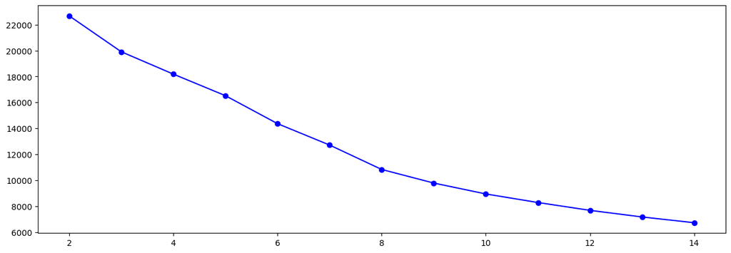

```python
## crating a dataframe of number of clusters and cluster errors.
# cluster_df = pd.Dataframe('num_clusters': cluster_range, 'cluster_errors':cluster_errors)
cluster_df = pd.DataFrame({'num_clusters': list(cluster_range), 'cluster_errors': cluster_errors})

## Elbow plot
plt.figure(figsize = [15,5])
plt.plot(cluster_df['num_clusters'],cluster_df['cluster_errors'],marker = 'o',color = 'b')
plt.show()
```

```python
# applying KMeans clustering for the optimal number of clusters obtained above
Kmeans = KMeans(n_clusters=3, random_state=100)
Kmeans.fit(pca_df)
```

```
KMeans(n_clusters=3, random_state=100)
```

```python
# creating a dataframe of the labels.
label = pd.DataFrame(Kmeans.labels_,columns=['Label'])
```

```python
# joining the label dataframe to the pca_df dataframe
Kmeans_df = pca_df.join(label)
Kmeans_df.head()
```

|  | PC1 | PC2 | PC3 | PC4 | PC5 | PC6 | PC7 | PC8 | Label |
| --- | --- | --- | --- | --- | --- | --- | --- | --- | --- |
| 0 | 2.037626 | 1.930346 | -1.011308 | -0.390638 | 0.022861 | -0.084544 | 0.002025 | 0.075497 | 1 |
| 1 | -1.390788 | 1.945534 | -0.695976 | -1.472914 | 0.453405 | 0.183625 | -0.299419 | -0.230509 | 2 |
| 2 | 1.310234 | -1.060111 | -1.279715 | -0.003618 | 0.015194 | -0.217794 | -0.219562 | 0.003792 | 1 |
| 3 | -1.739436 | -0.857641 | -1.456002 | 0.471940 | -0.313986 | -0.518453 | -0.648878 | -0.209979 | 0 |
| 4 | 0.046048 | -1.113891 | 1.187178 | -0.450188 | -1.405220 | 0.132862 | 1.489899 | -0.194330 | 0 |

```python
Kmeans_df['Label'].value_counts()
```

```
Label
0    900
1    756
2    584
Name: count, dtype: int64
```

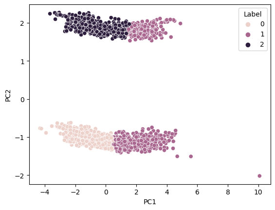

```python
# visualizing the clusters formed
sns.scatterplot(x=Kmeans_df['PC1'], y=Kmeans_df['PC2'], hue='Label', data=Kmeans_df)
plt.show()
```